# Forecasting Group Project

Yue Chen, Kai Kang, Jiaqian Ma, Yinzhe Huang

2022/1/1

Scale raw data before calculating. With function scale, we “scale” each element by those values by subtracting the mean and dividing by the standard deviation. In this way, time series are more stable.

## 1 Assessing the data and univariate benchmarks

### 1.1 Are these six variables stationary,

#### (a) using a simple method, e.g. looking at the time series plots and at the ACF/PACF?

##### ACF & PACF of Hoobies category

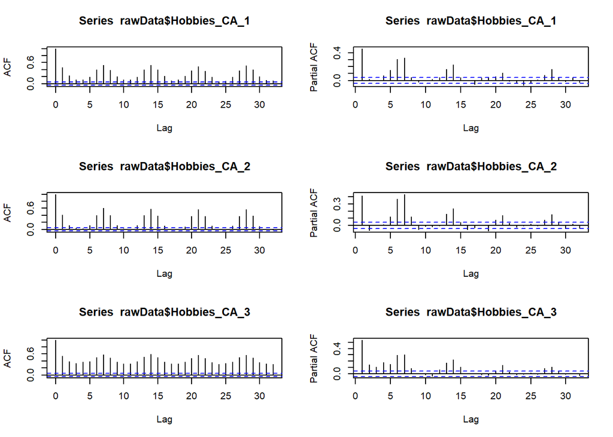

```r
par(mfrow=c(3,2))
acf(rawData$Hobbies_CA_1)
pacf(rawData$Hobbies_CA_1)
acf(rawData$Hobbies_CA_2)
pacf(rawData$Hobbies_CA_2)
acf(rawData$Hobbies_CA_3)
pacf(rawData$Hobbies_CA_3)
```

##### ACF & PACF of Household_1 category

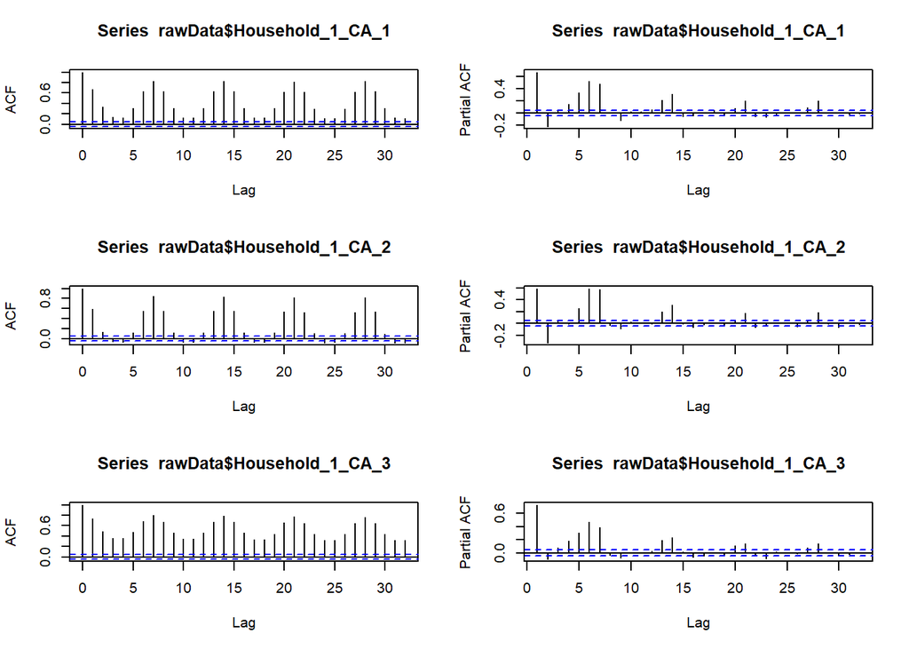

```r
par(mfrow=c(3,2))
acf(rawData$Household_1_CA_1)
pacf(rawData$Household_1_CA_1)
acf(rawData$Household_1_CA_2)
pacf(rawData$Household_1_CA_2)
acf(rawData$Household_1_CA_3)
pacf(rawData$Household_1_CA_3)
```

##### ACF & PACF of Household_2 category

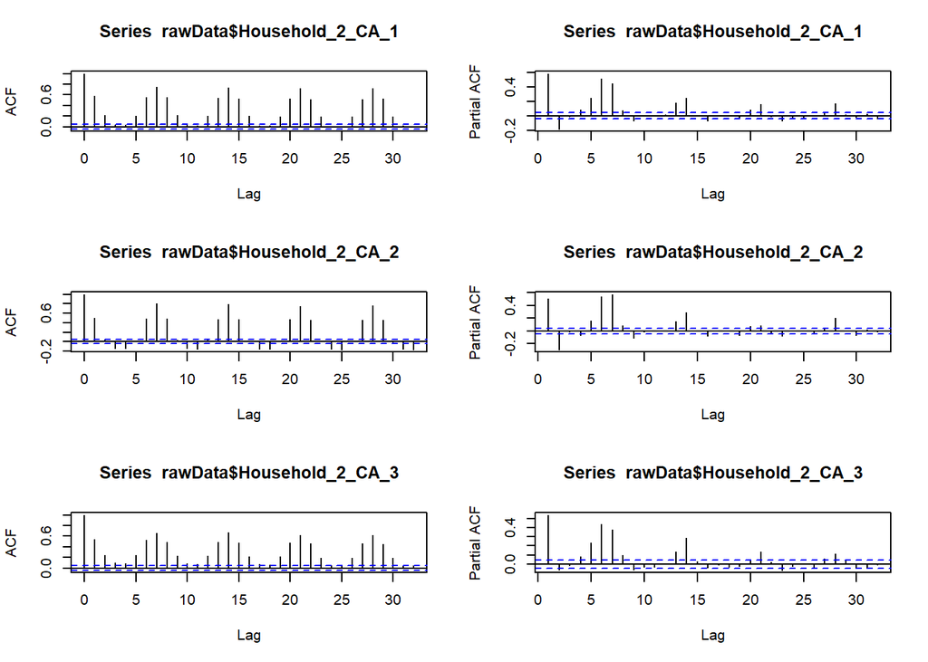

```r
par(mfrow=c(3,2))
acf(rawData$Household_2_CA_1)
pacf(rawData$Household_2_CA_1)
acf(rawData$Household_2_CA_2)
pacf(rawData$Household_2_CA_2)
acf(rawData$Household_2_CA_3)
pacf(rawData$Household_2_CA_3)
```

##### ACF & PACF of Foods_1 category

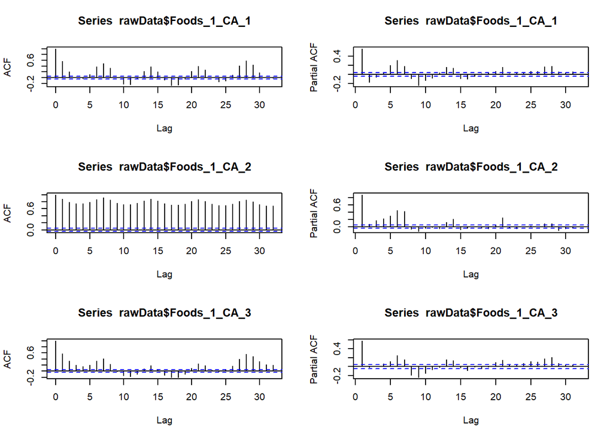

```r
par(mfrow=c(3,2))
acf(rawData$Foods_1_CA_1)
pacf(rawData$Foods_1_CA_1)
acf(rawData$Foods_1_CA_2)
pacf(rawData$Foods_1_CA_2)
acf(rawData$Foods_1_CA_3)
pacf(rawData$Foods_1_CA_3)
```

##### ACF & PACF of Food_2 category

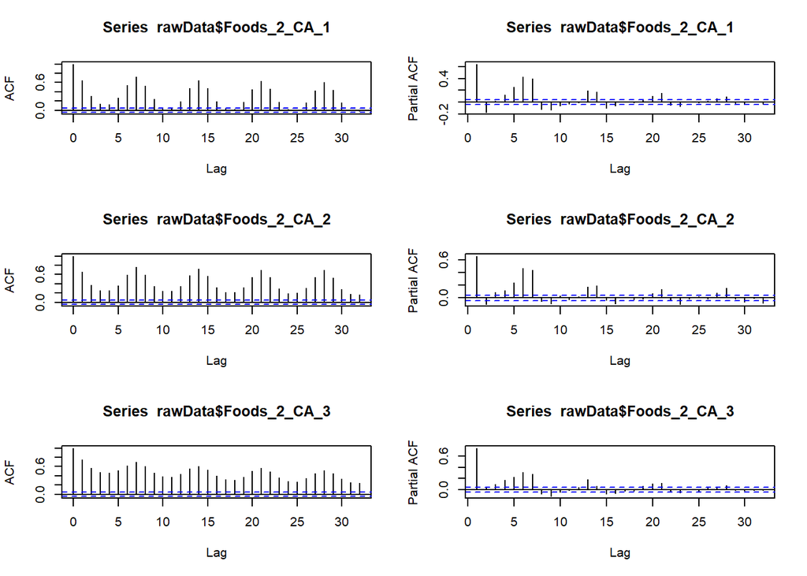

```r
par(mfrow=c(3,2))
acf(rawData$Foods_2_CA_1)
pacf(rawData$Foods_2_CA_1)
acf(rawData$Foods_2_CA_2)
pacf(rawData$Foods_2_CA_2)
acf(rawData$Foods_2_CA_3)
pacf(rawData$Foods_2_CA_3)
```

##### ACF & PACF of Foods_3 category

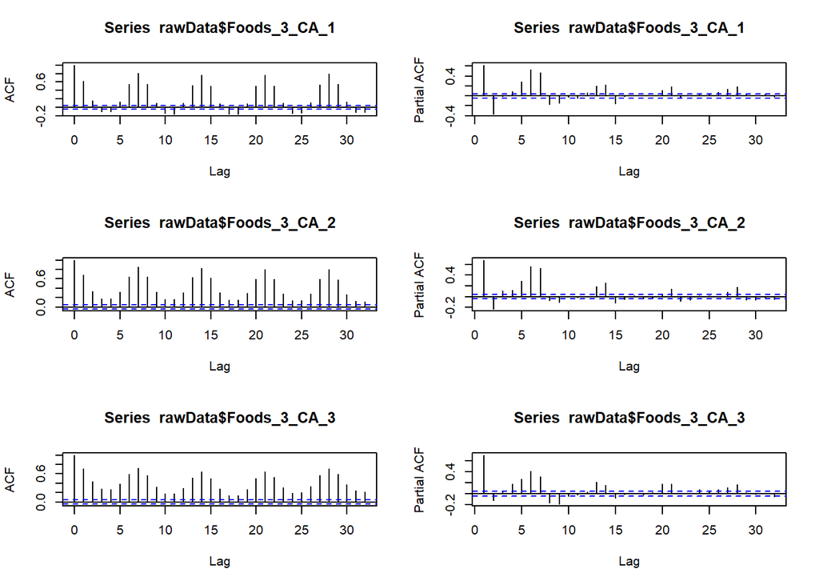

```r
par(mfrow=c(3,2))
acf(rawData$Foods_3_CA_1)
pacf(rawData$Foods_3_CA_1)
acf(rawData$Foods_3_CA_2)
pacf(rawData$Foods_3_CA_2)
acf(rawData$Foods_3_CA_3)
pacf(rawData$Foods_3_CA_3)
```

#### (b) performing a test?

```r
library(tseries)
adf.test(rawData$Hobbies_CA_1)
```

```
##
##  Augmented Dickey-Fuller Test
##
## data:  rawData$Hobbies_CA_1
## Dickey-Fuller = -7.2691, Lag order = 12, p-value = 0.01
## alternative hypothesis: stationary
```

```r
adf.test(rawData$Hobbies_CA_2)
```

```
##
##  Augmented Dickey-Fuller Test
##
## data:  rawData$Hobbies_CA_2
## Dickey-Fuller = -4.8925, Lag order = 12, p-value = 0.01
## alternative hypothesis: stationary
```

```r
adf.test(rawData$Hobbies_CA_3)
```

```
##
##  Augmented Dickey-Fuller Test
##
## data:  rawData$Hobbies_CA_3
## Dickey-Fuller = -6.872, Lag order = 12, p-value = 0.01
## alternative hypothesis: stationary
```

##### ADF Test for Houshold_1 category

```r
library(tseries)
adf.test(rawData$Household_1_CA_1)
```

```
##
##  Augmented Dickey-Fuller Test
##
## data:  rawData$Household_1_CA_1
## Dickey-Fuller = -5.9547, Lag order = 12, p-value = 0.01
## alternative hypothesis: stationary
```

```r
adf.test(rawData$Household_1_CA_2)
```

```
##
##  Augmented Dickey-Fuller Test
##
## data:  rawData$Household_1_CA_2
## Dickey-Fuller = -3.8192, Lag order = 12, p-value = 0.01803
## alternative hypothesis: stationary
```

```r
adf.test(rawData$Household_1_CA_3)
```

```
##
##  Augmented Dickey-Fuller Test
##
## data:  rawData$Household_1_CA_3
## Dickey-Fuller = -5.6101, Lag order = 12, p-value = 0.01
## alternative hypothesis: stationary
```

##### ADF Test for Houshold_2 category

```r
library(tseries)
adf.test(rawData$Household_2_CA_1)
```

```
##
##  Augmented Dickey-Fuller Test
##
## data:  rawData$Household_2_CA_1
## Dickey-Fuller = -5.6564, Lag order = 12, p-value = 0.01
## alternative hypothesis: stationary
```

```r
adf.test(rawData$Household_2_CA_2)
```

```
##
##  Augmented Dickey-Fuller Test
##
## data:  rawData$Household_2_CA_2
## Dickey-Fuller = -4.5383, Lag order = 12, p-value = 0.01
## alternative hypothesis: stationary
```

```r
adf.test(rawData$Household_2_CA_3)
```

```
##
##  Augmented Dickey-Fuller Test
##
## data:  rawData$Household_2_CA_3
## Dickey-Fuller = -5.5204, Lag order = 12, p-value = 0.01
## alternative hypothesis: stationary
```

##### ADF Test for Foods_1 category

```r
library(tseries)
adf.test(rawData$Foods_1_CA_1)
```

```
##
##  Augmented Dickey-Fuller Test
##
## data:  rawData$Foods_1_CA_1
## Dickey-Fuller = -10.85, Lag order = 12, p-value = 0.01
## alternative hypothesis: stationary
```

```r
adf.test(rawData$Foods_1_CA_2)
```

```
##
##  Augmented Dickey-Fuller Test
##
## data:  rawData$Foods_1_CA_2
## Dickey-Fuller = -2.1596, Lag order = 12, p-value = 0.5107
## alternative hypothesis: stationary
```

```r
adf.test(rawData$Foods_1_CA_3)
```

```
##
##  Augmented Dickey-Fuller Test
##
## data:  rawData$Foods_1_CA_3
## Dickey-Fuller = -11.661, Lag order = 12, p-value = 0.01
## alternative hypothesis: stationary
```

##### ADF Test for Foods_2 category

```r
library(tseries)
adf.test(rawData$Foods_2_CA_1)
```

```
##
##  Augmented Dickey-Fuller Test
##
## data:  rawData$Foods_2_CA_1
## Dickey-Fuller = -5.1882, Lag order = 12, p-value = 0.01
## alternative hypothesis: stationary
```

```r
adf.test(rawData$Foods_2_CA_2)
```

```
##
##  Augmented Dickey-Fuller Test
##
## data:  rawData$Foods_2_CA_2
## Dickey-Fuller = -3.4659, Lag order = 12, p-value = 0.04557
## alternative hypothesis: stationary
```

```r
adf.test(rawData$Foods_2_CA_3)
```

```
##
##  Augmented Dickey-Fuller Test
##
## data:  rawData$Foods_2_CA_3
## Dickey-Fuller = -4.4117, Lag order = 12, p-value = 0.01
## alternative hypothesis: stationary
```

##### ADF Test for Foods_3 category

```r
library(tseries)
adf.test(rawData$Foods_3_CA_1)
```

```
##
##  Augmented Dickey-Fuller Test
##
## data:  rawData$Foods_3_CA_1
## Dickey-Fuller = -5.2553, Lag order = 12, p-value = 0.01
## alternative hypothesis: stationary
```

```r
adf.test(rawData$Foods_3_CA_1)
```

```
##
##  Augmented Dickey-Fuller Test
##
## data:  rawData$Foods_3_CA_1
## Dickey-Fuller = -5.2553, Lag order = 12, p-value = 0.01
## alternative hypothesis: stationary
```

```r
adf.test(rawData$Foods_3_CA_1)
```

```
##
##  Augmented Dickey-Fuller Test
##
## data:  rawData$Foods_3_CA_1
## Dickey-Fuller = -5.2553, Lag order = 12, p-value = 0.01
## alternative hypothesis: stationary
```

### 1.2 We now want to assess the set of benchmark in the M5 guidelines. For several sample splits of your choice,

#### (a) Fit Statistical benchmarks 1 (Naive), 2 (sNaive), 3 (ES), 4 (MA), 13 (ESX), as well

#### as SARIMA, SARIMAX (using X as in ESX) and Holt-Winters up to the end of the

#### training subsample.

```r
# you can choose to summary different model(by change model_list) with different product(by change [1])
print(summary(ma_list[[1]]))
```

```
##             Length Class    Mode
## model           1  -none-   character
## timeElapsed     1  difftime numeric
## states      29280  mts      numeric
## transition    225  -none-   numeric
## persistence    15  -none-   numeric
## measurement    15  -none-   numeric
## order           1  -none-   numeric
## initial        15  -none-   numeric
## initialType     1  -none-   character
## nParam          8  -none-   numeric
## fitted       1941  ts       numeric
## forecast       10  ts       numeric
## lower           1  -none-   logical
## upper           1  -none-   logical
## residuals    1941  ts       numeric
## errors      19310  mts      numeric
## s2              1  -none-   numeric
## interval        1  -none-   character
## level           1  -none-   numeric
## cumulative      1  -none-   logical
## y            1941  ts       numeric
## holdout         1  -none-   logical
## occurrence      0  -none-   NULL
## ICs             4  -none-   numeric
## logLik          1  -none-   numeric
## lossValue       1  -none-   numeric
## loss            1  -none-   character
## accuracy        1  -none-   logical
```

```r
print(summary(arima_list[[2]]))
```

```
## Series: X[[i]]
## ARIMA(5,1,1)
##
## Coefficients:
##           ar1      ar2      ar3      ar4      ar5      ma1
##       -0.0675  -0.4351  -0.3787  -0.4023  -0.4544  -0.5639
## s.e.   0.0274   0.0186   0.0200   0.0190   0.0240   0.0276
##
## sigma^2 = 0.2732:  log likelihood = -1493.25
## AIC=3000.51   AICc=3000.57   BIC=3039.5
##
## Training set error measures:
##                       ME      RMSE       MAE      MPE     MAPE    MASE
## Training set 0.006626457 0.5217778 0.3888437 34.25395 201.5694 0.52478
##                     ACF1
## Training set -0.05248871
```

```r
print(summary(arimax_list_snap[[3]]))
```

```
## Series: column
## Regression with ARIMA(5,1,1) errors
##
## Coefficients:
##           ar1      ar2      ar3      ar4      ar5      ma1    xreg
##       -0.0844  -0.4331  -0.3840  -0.3759  -0.4639  -0.6031  0.1297
## s.e.   0.0265   0.0191   0.0202   0.0193   0.0234   0.0263  0.0234
##
## sigma^2 = 0.369:  log likelihood = -1784.01
## AIC=3584.02   AICc=3584.1   BIC=3628.58
##
## Training set error measures:
##                       ME      RMSE       MAE      MPE     MAPE      MASE
## Training set 0.005163125 0.6061666 0.4671498 50.37288 185.8899 0.6055345
##                     ACF1
## Training set -0.04510986
```

```r
print(summary(hw_list[[4]]))
```

```
## ETS(A,N,N)
##
## Call:
##  FUN(y = X[[i]])
##
##   Smoothing parameters:
##     alpha = 0.2929
##
##   Initial states:
##     l = 0.733
##
##   sigma:  0.9335
##
##      AIC     AICc      BIC
## 14432.03 14432.04 14448.74
##
## Training set error measures:
##                        ME      RMSE       MAE      MPE     MAPE     MASE
## Training set 0.0008422066 0.9330042 0.7542474 84.45161 249.5613 1.037576
##                   ACF1
## Training set 0.3575213
```

```r
print(summary(tbats_list[[5]]))
```

```
##                   Length Class  Mode
## lambda                0  -none- NULL
## alpha                 1  -none- numeric
## beta                  1  -none- numeric
## damping.parameter     1  -none- numeric
## gamma.one.values      3  -none- numeric
## gamma.two.values      3  -none- numeric
## ar.coefficients       5  -none- numeric
## ma.coefficients       4  -none- numeric
## likelihood            1  -none- numeric
## optim.return.code     1  -none- numeric
## variance              1  -none- numeric
## AIC                   1  -none- numeric
## parameters            2  -none- list
## seed.states          41  -none- numeric
## fitted.values      1941  msts   numeric
## errors             1941  msts   numeric
## x                 79581  -none- numeric
## seasonal.periods      3  -none- numeric
## k.vector              3  -none- numeric
## y                  1941  msts   numeric
## p                     1  -none- numeric
## q                     1  -none- numeric
## call                  2  -none- call
## series                1  -none- character
## method                1  -none- character
```

#### (b) Consider also a state-space model where the latent state variable follows a random walk.

#### Have a look as well at the TBATS package in R.

```r
print(summary(tbats_list[[1]]))
```

```
##                   Length Class  Mode
## lambda                0  -none- NULL
## alpha                 1  -none- numeric
## beta                  0  -none- NULL
## damping.parameter     0  -none- NULL
## gamma.one.values      3  -none- numeric
## gamma.two.values      3  -none- numeric
## ar.coefficients       0  -none- NULL
## ma.coefficients       1  -none- numeric
## likelihood            1  -none- numeric
## optim.return.code     1  -none- numeric
## variance              1  -none- numeric
## AIC                   1  -none- numeric
## parameters            2  -none- list
## seed.states          26  -none- numeric
## fitted.values      1941  msts   numeric
## errors             1941  msts   numeric
## x                 50466  -none- numeric
## seasonal.periods      3  -none- numeric
## k.vector              3  -none- numeric
## y                  1941  msts   numeric
## p                     1  -none- numeric
## q                     1  -none- numeric
## call                  2  -none- call
## series                1  -none- character
## method                1  -none- character
```

#### (c) Obtain a sequence of 1-step ahead point forecasts over the testing subsample.

```r
print(hybrid_crossH_RMSSE)
```

```
##    Hobbies_CA_1 Household_1_CA_1 Household_2_CA_1 Foods_1_CA_1 Foods_2_CA_1
## 1     1.2899420        1.0549149        0.7377539     1.059818    1.4716964
## 2     0.9866824        0.8721999        0.6073318     1.416372    1.2680317
## 3     0.8078319        0.7591792        0.4962857     1.513949    1.1668999
## 4     0.7000374        0.6786859        0.5872711     1.384295    1.0105651
## 5     0.8133559        0.6308991        0.5266280     1.277182    0.9898004
## 6     0.7440902        0.5772746        0.5319989     1.330512    1.0079592
## 7     0.6989415        0.7666331        0.5909348     1.248744    0.9399551
## 8     0.6732792        0.7788848        0.6057309     1.191681    0.9362997
## 9     0.6380163        0.7357470        0.5812806     1.128247    0.9363539
## 10    0.6489971        0.7036104        0.5863989     1.071519    0.9160408
## 11    0.7124414        0.6762948        0.5591101     1.115174    0.9176572
## 12    0.6827321        0.6568213        0.6009284     1.073781    0.8943869
## 13    0.6585554        0.7513342        0.6045288     1.036964    0.8757488
## 14    0.6537422        0.8289419        0.6426139     1.122875    0.8472852
```

[output cut: 69 more lines]

#### (d) Assess the quality of the forecasts using relevant loss functions.

We used RMSSE to evaluate the performance of each forecast model.

```r
cbind(naive_RMSSE_v
,snaive_RMSSE_v
,ses_RMSSE_v
,ma_RMSSE_v
,esx_holiday_RMSSE_v
,esx_snap_RMSSE_v
,arima_RMSSE_v
,arimax_snap_RMSSE_v
,hw_RMSSE_v
,tbats_RMSSE_v
)
```

```
##                  naive_RMSSE_v snaive_RMSSE_v ses_RMSSE_v ma_RMSSE_v
## Hobbies_CA_1         1.2427735      1.0181923   0.7432830  0.7399755
## Household_1_CA_1     1.4292742      1.1438067   0.9977895  0.9402688
## Household_2_CA_1     1.4085469      1.0136489   0.8310039  0.7644564
## Foods_1_CA_1         1.8254900      1.0862977   1.0423479  0.9463799
## Foods_2_CA_1         2.1408728      0.9621243   0.8214635  0.8392816
## Foods_3_CA_1         2.0665058      1.0342239   0.8393025  0.9006219
## Hobbies_CA_2         1.1646611      1.4712814   0.8353109  0.8185590
## Household_1_CA_2     2.2201519      1.5002971   1.2404832  1.3004096
## Household_2_CA_2     1.7717457      1.9288929   1.4034764  1.2481163
## Foods_1_CA_2         4.8679002      4.1877201   2.2159014  2.4196481
## Foods_2_CA_2         1.2316639      2.7514650   1.1563459  1.1542627
## Foods_3_CA_2         2.0275704      2.8899850   1.3113313  1.2867962
## Hobbies_CA_3         1.8023336      1.2092161   0.7844497  0.7714033
## Household_1_CA_3     2.4603089      1.1795553   0.9291308  0.9271046
## Household_2_CA_3     2.6926451      1.1629569   0.8576702  1.5628919
## Foods_1_CA_3         2.5510789      0.9746984   1.3634167  0.9688412
## Foods_2_CA_3         0.9370753      1.1278414   0.6722401  0.5989629
## Foods_3_CA_3         1.7055252      1.4046535   0.7110489  0.6758158
##                  esx_holiday_RMSSE_v esx_snap_RMSSE_v arima_RMSSE_v
## Hobbies_CA_1               0.7432830        0.7432830     0.7552578
## Household_1_CA_1           0.9977895        0.9977895     0.7164694
## Household_2_CA_1           0.8310039        0.8310039     0.5277707
## Foods_1_CA_1               1.0423479        1.0423479     0.9004924
## Foods_2_CA_1               0.8214635        0.8214635     0.7116430
## Foods_3_CA_1               0.8393025        0.8393025     0.6488804
## Hobbies_CA_2               0.8353109        0.8353109     0.6525421
## Household_1_CA_2           1.2404832        1.2404832     0.7242036
## Household_2_CA_2           1.4034764        1.4034764     0.8282719
## Foods_1_CA_2               2.2159014        2.2159014     1.9609898
## Foods_2_CA_2               1.1563459        1.1563459     0.8937472
## Foods_3_CA_2               1.3113313        1.3113313     0.7319230
## Hobbies_CA_3               0.7844497        0.7844497     0.7610982
## Household_1_CA_3           0.9291308        0.9291308     0.7192320
## Household_2_CA_3           0.8576702        0.8576702     1.3222435
## Foods_1_CA_3               1.3634167        1.3634167     1.0913744
## Foods_2_CA_3               0.6722401        0.6722401     0.5636294
## Foods_3_CA_3               0.7110489        0.7110489     0.5787541
##                  arimax_snap_RMSSE_v hw_RMSSE_v tbats_RMSSE_v
## Hobbies_CA_1               0.7669352  0.7433025     0.6440864
## Household_1_CA_1           0.6885691  0.9996970     0.4600701
## Household_2_CA_1           0.5166651  0.7992258     0.5044792
## Foods_1_CA_1               0.9483185  1.0422111     0.6544692
## Foods_2_CA_1               0.7909896  0.8212732     0.6678229
## Foods_3_CA_1               0.7034288  0.8368090     0.4938832
## Hobbies_CA_2               0.6543903  0.8257563     0.4871582
## Household_1_CA_2           0.7259534  1.2276921     0.6286102
## Household_2_CA_2           0.8206192  1.2890173     0.6804986
## Foods_1_CA_2               1.9413716  2.2159014     1.8684695
## Foods_2_CA_2               0.9008890  1.1562519     0.5357826
## Foods_3_CA_2               0.7282479  1.2903982     0.4873958
## Hobbies_CA_3               0.7717784  0.7844084     0.6830562
## Household_1_CA_3           0.7375147  0.9291320     0.7413378
## Household_2_CA_3           1.3635650  1.1206767     0.8089220
## Foods_1_CA_3               1.2367747  1.3634167     1.0085610
## Foods_2_CA_3               0.6152065  0.6722401     0.6813410
## Foods_3_CA_3               0.5160866  0.7110372     0.4335798
```

#### (e) Compare the above with combinations of the forecasting techniques (using simple averages across methods, such as Combination benchmark #21 in the M5 guidelines)

```r
print(hybrid_crossH_RMSSE)
```

```
##    Hobbies_CA_1 Household_1_CA_1 Household_2_CA_1 Foods_1_CA_1 Foods_2_CA_1
## 1     1.2899420        1.0549149        0.7377539     1.059818    1.4716964
## 2     0.9866824        0.8721999        0.6073318     1.416372    1.2680317
## 3     0.8078319        0.7591792        0.4962857     1.513949    1.1668999
## 4     0.7000374        0.6786859        0.5872711     1.384295    1.0105651
## 5     0.8133559        0.6308991        0.5266280     1.277182    0.9898004
## 6     0.7440902        0.5772746        0.5319989     1.330512    1.0079592
## 7     0.6989415        0.7666331        0.5909348     1.248744    0.9399551
## 8     0.6732792        0.7788848        0.6057309     1.191681    0.9362997
## 9     0.6380163        0.7357470        0.5812806     1.128247    0.9363539
## 10    0.6489971        0.7036104        0.5863989     1.071519    0.9160408
## 11    0.7124414        0.6762948        0.5591101     1.115174    0.9176572
## 12    0.6827321        0.6568213        0.6009284     1.073781    0.8943869
## 13    0.6585554        0.7513342        0.6045288     1.036964    0.8757488
## 14    0.6537422        0.8289419        0.6426139     1.122875    0.8472852
```

[output cut: 69 more lines]

We combine the ARIMA and ES models to get the hybrid model. Compared to the previous model, it’s worse than the state-space model, but better than the rest of the models.

#### (f) Compare the in-sample (training) vs. out-of-sample (testing) fit of the models.

```r
name_list = names(trainData[,2:19])

data.frame(cbind(naive_RMSE_train_v,naive_RMSE_test_v),row.names = name_list)
```

```
##                  naive_RMSE_train_v naive_RMSE_test_v
## Hobbies_CA_1              1.0337328         1.2846957
## Household_1_CA_1          0.8075364         1.1541909
## Household_2_CA_1          0.9134374         1.2866194
## Foods_1_CA_1              0.9300924         1.6978745
## Foods_2_CA_1              0.8479087         1.8152648
## Foods_3_CA_1              0.8691721         1.7961492
## Hobbies_CA_2              1.0827954         1.2610897
## Household_1_CA_2          0.9043951         2.0078946
## Household_2_CA_2          0.9868301         1.7484119
## Foods_1_CA_2              0.4697842         2.2868627
## Foods_2_CA_2              0.8219366         1.0123496
## Foods_3_CA_2              0.7922081         1.6062578
## Hobbies_CA_3              0.9619607         1.7337741
## Household_1_CA_3          0.7332903         1.8041205
## Household_2_CA_3          0.9616062         2.5892641
## Foods_1_CA_3              0.9163829         2.3377652
## Foods_2_CA_3              0.7167224         0.6716229
## Foods_3_CA_3              0.7664326         1.3071701
```

```r
data.frame(cbind(snaive_RMSE_train_v,snaive_RMSE_test_v),row.names = name_list)
```

```
##                  snaive_RMSE_train_v snaive_RMSE_test_v
## Hobbies_CA_1               1.1794916          1.0525388
## Household_1_CA_1           0.9317325          0.9236655
## Household_2_CA_1           0.9732685          0.9259047
## Foods_1_CA_1               1.0465776          1.0103573
## Foods_2_CA_1               1.2409495          0.8157936
## Foods_3_CA_1               1.0824455          0.8989186
## Hobbies_CA_2               1.3090846          1.5930968
## Household_1_CA_2           1.1716477          1.3568614
## Household_2_CA_2           1.1199862          1.9034895
## Foods_1_CA_2               1.1694892          1.9673248
## Foods_2_CA_2               1.2361908          2.2615298
## Foods_3_CA_2               1.2128587          2.2894697
## Hobbies_CA_3               1.1458664          1.1632183
## Household_1_CA_3           0.9504305          0.8649564
## Household_2_CA_3           1.0786499          1.1183066
## Foods_1_CA_3               1.0393981          0.8931970
## Foods_2_CA_3               1.3609128          0.8083492
## Foods_3_CA_3               1.1825266          1.0765723
```

```r
data.frame(cbind(ses_RMSE_train_v,ses_RMSE_test_v),row.names = name_list)
```

```
##                  ses_RMSE_train_v ses_RMSE_test_v
## Hobbies_CA_1            0.8687770       0.7683560
## Household_1_CA_1        0.7674631       0.8057513
## Household_2_CA_1        0.8385613       0.7590700
## Foods_1_CA_1            0.9330042       0.9694799
## Foods_2_CA_1            0.8379806       0.6965261
## Foods_3_CA_1            0.8809491       0.7294983
## Hobbies_CA_2            0.8922898       0.9044708
## Household_1_CA_2        0.8515735       1.1218870
## Household_2_CA_2        0.8950727       1.3849927
## Foods_1_CA_2            0.4315915       1.0409955
## Foods_2_CA_2            0.7622200       0.9504431
## Foods_3_CA_2            0.7609028       1.0388473
## Hobbies_CA_3            0.7695049       0.7546097
## Household_1_CA_3        0.6939846       0.6813226
## Household_2_CA_3        0.8461287       0.8247409
## Foods_1_CA_3            0.8785353       1.2494118
## Foods_2_CA_3            0.6934467       0.4818095
## Foods_3_CA_3            0.7752292       0.5449710
```

```r
data.frame(cbind(ma_RMSE_train_v,ma_RMSE_test_v),row.names = name_list)
```

```
##                  ma_RMSE_train_v ma_RMSE_test_v
## Hobbies_CA_1                 NaN      0.7649370
## Household_1_CA_1             NaN      0.7593013
## Household_2_CA_1             NaN      0.6982830
## Foods_1_CA_1                 NaN      0.8802208
## Foods_2_CA_1                 NaN      0.7116342
## Foods_3_CA_1                 NaN      0.7827955
## Hobbies_CA_2                 NaN      0.8863319
## Household_1_CA_2             NaN      1.1760841
## Household_2_CA_2             NaN      1.2316787
## Foods_1_CA_2                 NaN      1.1367125
## Foods_2_CA_2                 NaN      0.9487308
## Foods_3_CA_2                 NaN      1.0194105
## Hobbies_CA_3                 NaN      0.7420596
## Household_1_CA_3             NaN      0.6798367
## Household_2_CA_3             NaN      1.5028865
## Foods_1_CA_3                 NaN      0.8878296
## Foods_2_CA_3                 NaN      0.4292902
## Foods_3_CA_3                 NaN      0.5179673
```

```r
data.frame(cbind(esx_holiday_RMSE_train_v,esx_holiday_RMSE_test_v),row.names = name_list)
```

```
##                  esx_holiday_RMSE_train_v esx_holiday_RMSE_test_v
## Hobbies_CA_1                    0.8687770               0.7683560
## Household_1_CA_1                0.7674631               0.8057513
## Household_2_CA_1                0.8385613               0.7590700
## Foods_1_CA_1                    0.9330042               0.9694799
## Foods_2_CA_1                    0.8379806               0.6965261
## Foods_3_CA_1                    0.8809491               0.7294983
## Hobbies_CA_2                    0.8922898               0.9044708
## Household_1_CA_2                0.8515735               1.1218870
## Household_2_CA_2                0.8950727               1.3849927
## Foods_1_CA_2                    0.4315915               1.0409955
## Foods_2_CA_2                    0.7622200               0.9504431
## Foods_3_CA_2                    0.7609028               1.0388473
## Hobbies_CA_3                    0.7695049               0.7546097
## Household_1_CA_3                0.6939846               0.6813226
## Household_2_CA_3                0.8461287               0.8247409
## Foods_1_CA_3                    0.8785353               1.2494118
## Foods_2_CA_3                    0.6934467               0.4818095
## Foods_3_CA_3                    0.7752292               0.5449710
```

```r
data.frame(cbind(esx_snap_RMSE_train_v,esx_snap_RMSE_test_v),row.names = name_list)
```

```
##                  esx_snap_RMSE_train_v esx_snap_RMSE_test_v
## Hobbies_CA_1                 0.8687770            0.7683560
## Household_1_CA_1             0.7674631            0.8057513
## Household_2_CA_1             0.8385613            0.7590700
## Foods_1_CA_1                 0.9330042            0.9694799
## Foods_2_CA_1                 0.8379806            0.6965261
## Foods_3_CA_1                 0.8809491            0.7294983
## Hobbies_CA_2                 0.8922898            0.9044708
## Household_1_CA_2             0.8515735            1.1218870
## Household_2_CA_2             0.8950727            1.3849927
## Foods_1_CA_2                 0.4315915            1.0409955
## Foods_2_CA_2                 0.7622200            0.9504431
## Foods_3_CA_2                 0.7609028            1.0388473
## Hobbies_CA_3                 0.7695049            0.7546097
## Household_1_CA_3             0.6939846            0.6813226
## Household_2_CA_3             0.8461287            0.8247409
## Foods_1_CA_3                 0.8785353            1.2494118
## Foods_2_CA_3                 0.6934467            0.4818095
## Foods_3_CA_3                 0.7752292            0.5449710
```

```r
data.frame(cbind(arima_RMSE_train_v,arima_RMSE_test_v),row.names = name_list)
```

```
##                  arima_RMSE_train_v arima_RMSE_test_v
## Hobbies_CA_1              0.7975373         0.7807348
## Household_1_CA_1          0.5217778         0.5785751
## Household_2_CA_1          0.6108511         0.4820855
## Foods_1_CA_1              0.7575955         0.8375412
## Foods_2_CA_1              0.6354334         0.6034083
## Foods_3_CA_1              0.5595685         0.5639887
## Hobbies_CA_2              0.7747392         0.7065696
## Household_1_CA_2          0.5241197         0.6549663
## Household_2_CA_2          0.5895493         0.8173636
## Foods_1_CA_2              0.3414760         0.9212421
## Foods_2_CA_2              0.5950037         0.7346036
## Foods_3_CA_2              0.5012368         0.5798353
## Hobbies_CA_3              0.7359160         0.7321466
## Household_1_CA_3          0.5255288         0.5274058
## Household_2_CA_3          0.6918074         1.2714775
## Foods_1_CA_3              0.7942293         1.0001168
## Foods_2_CA_3              0.5998747         0.4039658
## Foods_3_CA_3              0.5954681         0.4435760
```

```r
data.frame(cbind(arimax_RMSE_train_v,arimax_RMSE_test_v),row.names = name_list)
```

```
##                  arimax_RMSE_train_v arimax_RMSE_test_v
## Hobbies_CA_1               0.7933479          0.7928061
## Household_1_CA_1           0.5129098          0.5560446
## Household_2_CA_1           0.6061666          0.4719412
## Foods_1_CA_1               0.7054227          0.8820239
## Foods_2_CA_1               0.6251754          0.6706870
## Foods_3_CA_1               0.5233307          0.6114007
## Hobbies_CA_2               0.7747006          0.7085708
## Household_1_CA_2           0.5235797          0.6565488
## Household_2_CA_2           0.5877971          0.8098117
## Foods_1_CA_2               0.3385487          0.9120258
## Foods_2_CA_2               0.5934265          0.7404736
## Foods_3_CA_2               0.4980875          0.5769239
## Hobbies_CA_3               0.7331901          0.7424204
## Household_1_CA_3           0.5181741          0.5408123
## Household_2_CA_3           0.6875080          1.3112125
## Foods_1_CA_3               0.7243906          1.1333592
## Foods_2_CA_3               0.5926980          0.4409323
## Foods_3_CA_3               0.5539601          0.3955456
```

```r
data.frame(cbind(hw_RMSE_train_v,hw_RMSE_test_v),row.names = name_list)
```

```
##                  hw_RMSE_train_v hw_RMSE_test_v
## Hobbies_CA_1           0.8687771      0.7683762
## Household_1_CA_1       0.7625522      0.8072918
## Household_2_CA_1       0.8338279      0.7300427
## Foods_1_CA_1           0.9330042      0.9693526
## Foods_2_CA_1           0.8379806      0.6963647
## Foods_3_CA_1           0.8789634      0.7273310
## Hobbies_CA_2           0.8904003      0.8941251
## Household_1_CA_2       0.8460326      1.1103188
## Household_2_CA_2       0.8893638      1.2720410
## Foods_1_CA_2           0.4315915      1.0409955
## Foods_2_CA_2           0.7622202      0.9503657
## Foods_3_CA_2           0.7558879      1.0222640
## Hobbies_CA_3           0.7695049      0.7545700
## Household_1_CA_3       0.6939846      0.6813234
## Household_2_CA_3       0.8426403      1.0776496
## Foods_1_CA_3           0.8785353      1.2494118
## Foods_2_CA_3           0.6934467      0.4818095
## Foods_3_CA_3           0.7752292      0.5449621
```

```r
data.frame(cbind(tbats_RMSE_train_v,tbats_RMSE_test_v),row.names = name_list)
```

```
##                  tbats_RMSE_train_v tbats_RMSE_test_v
## Hobbies_CA_1              0.6926569         0.6658133
## Household_1_CA_1          0.4137744         0.3715233
## Household_2_CA_1          0.5012038         0.4608101
## Foods_1_CA_1              0.6060818         0.6087168
## Foods_2_CA_1              0.5246517         0.5662529
## Foods_3_CA_1              0.4134319         0.4292695
## Hobbies_CA_2              0.6549367         0.5274926
## Household_1_CA_2          0.4142402         0.5685120
## Household_2_CA_2          0.4675904         0.6715365
## Foods_1_CA_2              0.3325849         0.8777775
## Foods_2_CA_2              0.5049581         0.4403793
## Foods_3_CA_2              0.3966056         0.3861189
## Hobbies_CA_3              0.6538240         0.6570732
## Household_1_CA_3          0.4530124         0.5436158
## Household_2_CA_3          0.5834173         0.7778644
## Foods_1_CA_3              0.6099101         0.9242281
## Foods_2_CA_3              0.5288684         0.4883323
## Foods_3_CA_3              0.4632731         0.3323097
```

#### (g) Do you find similarities in terms of forecast performance across stores or types of items?

No

### 1.3 Consider varying the horizon, h, and obtaining forecasts for h = 1, …, 28. Do you find different

### rankings of models according to the RMSSE (Root Mean Square Scaled Error) suggested in

### the M5 guidelines.

```r
print(naive_crossH_RMSSE)
```

```
##    Hobbies_CA_1 Household_1_CA_1 Household_2_CA_1 Foods_1_CA_1 Foods_2_CA_1
## 1      2.119970         2.178688         2.108515     1.946816     2.730975
## 2      1.880783         2.135898         2.142793     2.481713     2.748388
## 3      1.667489         2.121443         2.015883     2.717576     2.817490
## 4      1.572694         2.101465         2.112967     2.661945     2.609733
## 5      1.409408         2.023748         1.955404     2.560933     2.549220
## 6      1.338830         1.873348         1.788483     2.575963     2.475992
## 7      1.302655         1.751159         1.655864     2.450222     2.337873
## 8      1.298326         1.639439         1.560820     2.367370     2.315499
## 9      1.248166         1.623213         1.593801     2.250535     2.353566
## 10     1.187261         1.651231         1.670324     2.188080     2.386153
## 11     1.311500         1.622216         1.655265     2.261284     2.421916
## 12     1.280774         1.574692         1.586285     2.220159     2.388933
## 13     1.245722         1.518863         1.526416     2.144117     2.340023
## 14     1.202807         1.472523         1.470919     2.078233     2.279506
```

[output cut: 101 more lines]

```r
print(snaive_crossH_RMSSE)
```

```
##    Hobbies_CA_1 Household_1_CA_1 Household_2_CA_1 Foods_1_CA_1 Foods_2_CA_1
## 1     2.7209922         2.230562        2.5506230    0.0270391    0.1157193
## 2     1.9353102         1.812277        1.8347158    0.5165814    0.3931903
## 3     1.6138719         1.486304        1.6400562    0.6074277    0.3820490
## 4     1.4241035         1.287903        1.4285513    0.5590625    0.6316779
## 5     1.4599805         1.194769        1.3727734    0.6709840    0.8206122
## 6     1.3593875         1.197386        1.3440812    0.6266814    0.8590420
## 7     1.2767426         1.199251        1.2467651    0.6339585    0.8022158
## 8     1.3291569         1.216558        1.2207514    0.5933220    0.7680419
## 9     1.2679248         1.174684        1.1523303    0.6422064    0.7267421
## 10    1.2142417         1.117029        1.0931965    0.6456630    0.6894481
## 11    1.1693963         1.085270        1.0425237    0.6199727    0.6828775
## 12    1.1632034         1.076008        1.1395320    0.7147058    0.7101668
## 13    1.1337637         1.197440        1.1308032    0.7554589    0.7473325
## 14    1.0967649         1.182547        1.1005698    0.8473211    0.7537887
```

[output cut: 101 more lines]

```r
print(ses_crossH_RMSSE)
```

```
##    Hobbies_CA_1 Household_1_CA_1 Household_2_CA_1 Foods_1_CA_1 Foods_2_CA_1
## 1     1.2292681        0.9841239        0.7598792    0.8312302    1.1276315
## 2     1.0058030        0.9418885        0.7946156    1.4049309    1.1451209
## 3     0.8323528        0.9273826        0.6859689    1.6362461    1.2163271
## 4     0.7423774        0.9076734        0.7868564    1.5743508    1.0606532
## 5     0.8230353        0.8400552        0.7110290    1.4765699    0.9973109
## 6     0.7513545        0.7870414        0.7838806    1.4863382    0.9302507
## 7     0.6985554        1.0057976        0.8795339    1.3832296    0.8736597
## 8     0.6668881        1.0056182        0.8705087    1.3089981    0.8399708
## 9     0.6309654        0.9531053        0.8366763    1.2369531    0.8638254
## 10    0.6296327        0.9301627        0.8427873    1.1802272    0.8851856
## 11    0.7179129        0.8874113        0.8047997    1.2464210    0.9125299
## 12    0.6873657        0.8539009        0.8345713    1.2053637    0.8807956
## 13    0.6625282        0.9433106        0.8523742    1.1617189    0.8463133
## 14    0.6586896        1.0284168        0.9006644    1.2352560    0.8209844
```

[output cut: 101 more lines]

```r
print(esx_holiday_crossH_RMSSE)
```

```
##    Hobbies_CA_1 Household_1_CA_1 Household_2_CA_1 Foods_1_CA_1 Foods_2_CA_1
## 1     1.2292681        0.9841239        0.7598792    0.8312302    1.1276315
## 2     1.0058030        0.9418885        0.7946156    1.4049309    1.1451209
## 3     0.8323528        0.9273826        0.6859689    1.6362461    1.2163271
## 4     0.7423774        0.9076734        0.7868564    1.5743508    1.0606532
## 5     0.8230353        0.8400552        0.7110290    1.4765699    0.9973109
## 6     0.7513545        0.7870414        0.7838806    1.4863382    0.9302507
## 7     0.6985554        1.0057976        0.8795339    1.3832296    0.8736597
## 8     0.6668881        1.0056182        0.8705087    1.3089981    0.8399708
## 9     0.6309654        0.9531053        0.8366763    1.2369531    0.8638254
## 10    0.6296327        0.9301627        0.8427873    1.1802272    0.8851856
## 11    0.7179129        0.8874113        0.8047997    1.2464210    0.9125299
## 12    0.6873657        0.8539009        0.8345713    1.2053637    0.8807956
## 13    0.6625282        0.9433106        0.8523742    1.1617189    0.8463133
## 14    0.6586896        1.0284168        0.9006644    1.2352560    0.8209844
```

[output cut: 101 more lines]

```r
print(esx_snap_crossH_RMSSE)
```

```
##    Hobbies_CA_1 Household_1_CA_1 Household_2_CA_1 Foods_1_CA_1 Foods_2_CA_1
## 1     1.2292681        0.9841239        0.7598792    0.8312302    1.1276315
## 2     1.0058030        0.9418885        0.7946156    1.4049309    1.1451209
## 3     0.8323528        0.9273826        0.6859689    1.6362461    1.2163271
## 4     0.7423774        0.9076734        0.7868564    1.5743508    1.0606532
## 5     0.8230353        0.8400552        0.7110290    1.4765699    0.9973109
## 6     0.7513545        0.7870414        0.7838806    1.4863382    0.9302507
## 7     0.6985554        1.0057976        0.8795339    1.3832296    0.8736597
## 8     0.6668881        1.0056182        0.8705087    1.3089981    0.8399708
## 9     0.6309654        0.9531053        0.8366763    1.2369531    0.8638254
## 10    0.6296327        0.9301627        0.8427873    1.1802272    0.8851856
## 11    0.7179129        0.8874113        0.8047997    1.2464210    0.9125299
## 12    0.6873657        0.8539009        0.8345713    1.2053637    0.8807956
## 13    0.6625282        0.9433106        0.8523742    1.1617189    0.8463133
## 14    0.6586896        1.0284168        0.9006644    1.2352560    0.8209844
```

[output cut: 101 more lines]

```r
print(arima_crossH_RMSSE)
```

```
##    X1.35048632460751 X1.16476669000305 X0.718048813068774 X1.28872330936905
## 1          1.3504863         1.1647667          0.7180488         1.2887233
## 2          0.9862056         0.8750373          0.5084616         1.4500232
## 3          0.8446662         0.7150244          0.4603273         1.4219216
## 4          0.7426642         0.6230929          0.4781015         1.2479415
## 5          0.8637042         0.5751879          0.4276312         1.1310151
## 6          0.7936701         0.5366453          0.3926696         1.2231709
## 7          0.7546907         0.6346231          0.4075965         1.1640696
## 8          0.7306195         0.6414200          0.4508545         1.1227564
## 9          0.6929795         0.6047414          0.4257090         1.0656219
## 10         0.7118945         0.5746346          0.4124611         1.0112677
## 11         0.7472138         0.5813690          0.4004035         1.0285889
## 12         0.7174019         0.5712303          0.4623617         0.9865447
## 13         0.6922283         0.6475242          0.4559246         0.9551054
## 14         0.6841471         0.7014789          0.4855334         1.0484450
```

[output cut: 130 more lines]

```r
print(arimax_crossH_RMSSE)
```

```
##    X1.33393691192193 X1.16611493621022 X0.718751872003902 X1.24791194648984
## 1          1.3339369         1.1661149          0.7187519         1.2479119
## 2          0.9718770         0.8747228          0.5087855         1.3670413
## 3          0.8363807         0.7146235          0.4619145         1.3244649
## 4          0.7366062         0.6230199          0.4787974         1.1560059
## 5          0.8622053         0.5744629          0.4282518         1.0447135
## 6          0.7919662         0.5359915          0.3932090         1.1613219
## 7          0.7524267         0.6322807          0.4073406         1.1144217
## 8          0.7276871         0.6386650          0.4504425         1.0786032
## 9          0.6906457         0.6021412          0.4252398         1.0276228
## 10         0.6951999         0.5720556          0.4229144         0.9897571
## 11         0.7501802         0.5620044          0.4046463         1.0880952
## 12         0.7184254         0.5427760          0.4446432         1.0720795
## 13         0.6908134         0.5946616          0.4317667         1.0344883
## 14         0.6759413         0.6303105          0.4485096         1.0365006
```

[output cut: 130 more lines]

```r
print(hw_crossH_RMSSE)
```

```
##    Hobbies_CA_1 Household_1_CA_1 Household_2_CA_1 Foods_1_CA_1 Foods_2_CA_1
## 1     1.2293976        0.9450631        0.7574589    0.8309123    1.1272567
## 2     1.0059283        0.9037698        0.8004399    1.4046327    1.1447462
## 3     0.8324659        0.8901513        0.6958073    1.6359445    1.2159535
## 4     0.7424880        0.8712842        0.8067998    1.5740464    1.0603099
## 5     0.8230809        0.8049218        0.7257685    1.4762675    0.9969671
## 6     0.7513965        0.7588620        0.7808516    1.4860332    0.9299122
## 7     0.6985987        0.9948840        0.8615801    1.3829364    0.8733745
## 8     0.6669370        0.9996540        0.8452463    1.3087100    0.8396807
## 9     0.6310076        0.9466324        0.8200449    1.2366892    0.8635247
## 10    0.6296581        0.9223069        0.8393332    1.1799676    0.8848767
## 11    0.7179545        0.8796963        0.8039664    1.2461563    0.9122146
## 12    0.6874054        0.8472676        0.8217238    1.2050999    0.8804824
## 13    0.6625633        0.9409219        0.8298928    1.1614732    0.8460110
## 14    0.6587139        1.0291361        0.8673834    1.2350774    0.8207066
```

[output cut: 101 more lines]

```r
print(tbats_crossH_RMSSE)
```

```
##    Hobbies_CA_1 Household_1_CA_1 Household_2_CA_1 Foods_1_CA_1 Foods_2_CA_1
## 1     0.9498968        0.8618112        0.4378411    0.2499997    0.8013042
## 2     0.6722480        0.6424856        0.3111161    0.3552853    0.5924215
## 3     0.6042899        0.5263092        0.4512353    0.4165050    0.5237342
## 4     0.5418142        0.4559720        0.4063982    0.3754497    0.5985698
## 5     0.7131873        0.4147052        0.3778806    0.3369779    0.5531760
## 6     0.7418390        0.4191936        0.3543616    0.6514700    0.7006078
## 7     0.7366712        0.4326822        0.3322215    0.6508936    0.6809434
## 8     0.7064906        0.4985102        0.4319020    0.6111200    0.6547332
## 9     0.6727798        0.4713935        0.4095167    0.6494735    0.6646427
## 10    0.6731643        0.4664723        0.4208702    0.6179124    0.6743564
## 11    0.7416557        0.4491068        0.4018899    0.7145844    0.6762081
## 12    0.7157606        0.4325157        0.4399830    0.7100892    0.6602406
## 13    0.7281764        0.4382077        0.4356389    0.7010630    0.7101626
## 14    0.7020586        0.4329242        0.4233601    0.7103182    0.7279857
```

[output cut: 101 more lines]

### 1.4 Now, in this question only, aggregate the data at the store or type of item level.

#### (a) Produce forecasts for these aggregates using the previous methods and assess them.

```r
# model
print(summary(ma_cat_list[[1]]))
```

```
##             Length Class    Mode
## model           1  -none-   character
## timeElapsed     1  difftime numeric
## states      15616  mts      numeric
## transition     64  -none-   numeric
## persistence     8  -none-   numeric
## measurement     8  -none-   numeric
## order           1  -none-   numeric
## initial         8  -none-   numeric
## initialType     1  -none-   character
## nParam          8  -none-   numeric
## fitted       1941  ts       numeric
## forecast       10  ts       numeric
## lower           1  -none-   logical
## upper           1  -none-   logical
## residuals    1941  ts       numeric
## errors      19310  mts      numeric
## s2              1  -none-   numeric
## interval        1  -none-   character
## level           1  -none-   numeric
## cumulative      1  -none-   logical
## y            1941  ts       numeric
## holdout         1  -none-   logical
## occurrence      0  -none-   NULL
## ICs             4  -none-   numeric
## logLik          1  -none-   numeric
## lossValue       1  -none-   numeric
## loss            1  -none-   character
## accuracy        1  -none-   logical
```

```r
print(summary(cat_ses_list[[1]]))
```

```
##
## Forecast method: Simple exponential smoothing
##
## Model Information:
## Simple exponential smoothing
##
## Call:
##  FUN(y = X[[i]], h = 4)
##
##   Smoothing parameters:
##     alpha = 0.0462
##
##   Initial states:
##     l = -0.8115
##
##   sigma:  2.0702
##
##      AIC     AICc      BIC
## 17523.94 17523.96 17540.66
##
## Error measures:
##                      ME    RMSE      MAE      MPE     MAPE      MASE      ACF1
## Training set 0.03930888 2.06913 1.607498 43.14076 200.0844 0.9209994 0.3378844
##
## Forecasts:
##      Point Forecast      Lo 80    Hi 80     Lo 95    Hi 95
## 1942       2.712595 0.05953064 5.365659 -1.344917 6.770107
## 1943       2.712595 0.05670213 5.368488 -1.349243 6.774433
## 1944       2.712595 0.05387664 5.371313 -1.353564 6.778754
## 1945       2.712595 0.05105415 5.374136 -1.357880 6.783070
```

```r
print(summary(cat_esx_holiday_list[[1]]))
```

```
##
## Forecast method: Simple exponential smoothing
##
## Model Information:
## Simple exponential smoothing
##
## Call:
##  FUN(y = X[[i]], h = 4)
##
##   Smoothing parameters:
##     alpha = 0.0462
##
##   Initial states:
##     l = -0.8115
##
##   sigma:  2.0702
##
##      AIC     AICc      BIC
## 17523.94 17523.96 17540.66
##
## Error measures:
##                      ME    RMSE      MAE      MPE     MAPE      MASE      ACF1
## Training set 0.03930888 2.06913 1.607498 43.14076 200.0844 0.9209994 0.3378844
##
## Forecasts:
##      Point Forecast      Lo 80    Hi 80     Lo 95    Hi 95
## 1942       2.712595 0.05953064 5.365659 -1.344917 6.770107
## 1943       2.712595 0.05670213 5.368488 -1.349243 6.774433
## 1944       2.712595 0.05387664 5.371313 -1.353564 6.778754
## 1945       2.712595 0.05105415 5.374136 -1.357880 6.783070
```

```r
print(summary(cat_esx_snap_list[[1]]))
```

```
##
## Forecast method: Simple exponential smoothing
##
## Model Information:
## Simple exponential smoothing
##
## Call:
##  FUN(y = X[[i]], h = 4)
##
##   Smoothing parameters:
##     alpha = 0.0462
##
##   Initial states:
##     l = -0.8115
##
##   sigma:  2.0702
##
##      AIC     AICc      BIC
## 17523.94 17523.96 17540.66
##
## Error measures:
##                      ME    RMSE      MAE      MPE     MAPE      MASE      ACF1
## Training set 0.03930888 2.06913 1.607498 43.14076 200.0844 0.9209994 0.3378844
##
## Forecasts:
##      Point Forecast      Lo 80    Hi 80     Lo 95    Hi 95
## 1942       2.712595 0.05953064 5.365659 -1.344917 6.770107
## 1943       2.712595 0.05670213 5.368488 -1.349243 6.774433
## 1944       2.712595 0.05387664 5.371313 -1.353564 6.778754
## 1945       2.712595 0.05105415 5.374136 -1.357880 6.783070
```

```r
print(summary(cat_hw_list[[1]]))
```

```
## ETS(A,N,N)
##
## Call:
##  FUN(y = X[[i]])
##
##   Smoothing parameters:
##     alpha = 0.0461
##
##   Initial states:
##     l = -0.7987
##
##   sigma:  2.0702
##
##      AIC     AICc      BIC
## 17523.94 17523.96 17540.66
##
## Training set error measures:
##                      ME     RMSE      MAE      MPE     MAPE      MASE      ACF1
## Training set 0.03919662 2.069131 1.607521 43.14266 200.0657 0.6820464 0.3379189
```

```r
print(summary(cat_tbats_list[[1]]))
```

```
##                   Length Class  Mode
## lambda                0  -none- NULL
## alpha                 1  -none- numeric
## beta                  0  -none- NULL
## damping.parameter     0  -none- NULL
## gamma.one.values      3  -none- numeric
## gamma.two.values      3  -none- numeric
## ar.coefficients       1  -none- numeric
## ma.coefficients       0  -none- NULL
## likelihood            1  -none- numeric
## optim.return.code     1  -none- numeric
## variance              1  -none- numeric
## AIC                   1  -none- numeric
## parameters            2  -none- list
## seed.states          36  -none- numeric
## fitted.values      1941  msts   numeric
## errors             1941  msts   numeric
## x                 69876  -none- numeric
## seasonal.periods      3  -none- numeric
## k.vector              3  -none- numeric
## y                  1941  msts   numeric
## p                     1  -none- numeric
## q                     1  -none- numeric
## call                  2  -none- call
## series                1  -none- character
## method                1  -none- character
```

#### (b) Compare the forecasts of the aggregates to the aggregates of the forecasts that you

#### had obtained in previous questions, can you find systematic pattern in terms of relative

#### forecasting performance?

```r
print(cbind(naive_cat_RMSSE_v
,snaive_cat_RMSSE_v
,ma_cat_RMSSE_v
,cat_ses_RMSSE_v
,cat_esx_holiday_RMSSE_v
,cat_esx_snap_RMSSE_v
,cat_arima_RMSSE_v
,cat_arimax_RMSSE_v
,cat_hw_RMSSE_v
,cat_tbats_RMSSE_v
))
```

```
##           naive_cat_RMSSE_v snaive_cat_RMSSE_v ma_cat_RMSSE_v cat_ses_RMSSE_v
## Hobbies            1.715501           1.130764       0.934520       0.6518770
## Foods              2.413166           1.686916       1.069649       1.2149773
## Household          2.255322           1.257439       1.124647       0.7602873
##           cat_esx_holiday_RMSSE_v cat_esx_snap_RMSSE_v cat_arima_RMSSE_v
## Hobbies                 0.6518770            0.6518770         0.6703985
## Foods                   1.2149773            1.2149773         0.7385231
## Household               0.7602873            0.7602873         0.5661855
##           cat_arimax_RMSSE_v cat_hw_RMSSE_v cat_tbats_RMSSE_v
## Hobbies            0.6954853      0.6504478         0.5480312
## Foods              0.7426418      0.6085078         0.5671615
## Household          0.5741374      0.5564988         0.4219446
```

First, we calculate the arithmetic mean of RMSSE from previous forecast models, and compare them with the results from aggregated forecast models.Use the state-space model as example, values of forecasts of the aggregates are smaller than the values of aggregates of the previous forecasts. For Hobbies, aggregates of the previous forecasts and forecasts of the aggregates are 0.6, 0.54, for foods are 0.76, 0.56, for Households are 0.63 and 0.42. Thus, we can infer aggregate before forecasting will result in better forecasting performance.

### 1.5 Now, in this question only, aggregate the data at the weekly frequency,

#### (a) produce forecasts for the weekly aggregates using the previous methods and assess them

```r
# model
print(summary(ma_week_list[[1]]))
```

```
##             Length Class    Mode
## model          1   -none-   character
## timeElapsed    1   difftime numeric
## states      2016   mts      numeric
## transition    49   -none-   numeric
## persistence    7   -none-   numeric
## measurement    7   -none-   numeric
## order          1   -none-   numeric
## initial        7   -none-   numeric
## initialType    1   -none-   character
## nParam         8   -none-   numeric
## fitted       277   ts       numeric
## forecast      10   ts       numeric
## lower          1   -none-   logical
## upper          1   -none-   logical
## residuals    277   ts       numeric
## errors      2670   mts      numeric
## s2             1   -none-   numeric
## interval       1   -none-   character
## level          1   -none-   numeric
## cumulative     1   -none-   logical
## y            277   ts       numeric
## holdout        1   -none-   logical
## occurrence     0   -none-   NULL
## ICs            4   -none-   numeric
## logLik         1   -none-   numeric
## lossValue      1   -none-   numeric
## loss           1   -none-   character
## accuracy       1   -none-   logical
```

```r
print(summary(week_ses_list[[1]]))
```

```
##
## Forecast method: Simple exponential smoothing
##
## Model Information:
## Simple exponential smoothing
##
## Call:
##  FUN(y = X[[i]], h = 4)
##
##   Smoothing parameters:
##     alpha = 0.2677
##
##   Initial states:
##     l = -1.2052
##
##   sigma:  2.5725
##
##      AIC     AICc      BIC
## 2085.307 2085.394 2096.179
##
## Error measures:
##                      ME     RMSE      MAE     MPE     MAPE      MASE
## Training set 0.08279188 2.563189 1.920029 8.15123 170.4634 0.8071932
##                     ACF1
## Training set 0.003292809
##
## Forecasts:
##     Point Forecast    Lo 80    Hi 80      Lo 95     Hi 95
## 278       4.934645 1.637863 8.231427 -0.1073476  9.976638
## 279       4.934645 1.521755 8.347535 -0.2849192 10.154209
## 280       4.934645 1.409470 8.459820 -0.4566453 10.325935
## 281       4.934645 1.300652 8.568638 -0.6230678 10.492358
```

```r
print(summary(ma_week_list[[1]]))
```

```
##             Length Class    Mode
## model          1   -none-   character
## timeElapsed    1   difftime numeric
## states      2016   mts      numeric
## transition    49   -none-   numeric
## persistence    7   -none-   numeric
## measurement    7   -none-   numeric
## order          1   -none-   numeric
## initial        7   -none-   numeric
## initialType    1   -none-   character
## nParam         8   -none-   numeric
## fitted       277   ts       numeric
## forecast      10   ts       numeric
## lower          1   -none-   logical
## upper          1   -none-   logical
## residuals    277   ts       numeric
## errors      2670   mts      numeric
## s2             1   -none-   numeric
## interval       1   -none-   character
## level          1   -none-   numeric
## cumulative     1   -none-   logical
## y            277   ts       numeric
## holdout        1   -none-   logical
## occurrence     0   -none-   NULL
## ICs            4   -none-   numeric
## logLik         1   -none-   numeric
## lossValue      1   -none-   numeric
## loss           1   -none-   character
## accuracy       1   -none-   logical
```

```r
print(summary(week_esx_holiday_list[[1]]))
```

```
##
## Forecast method: Simple exponential smoothing
##
## Model Information:
## Simple exponential smoothing
##
## Call:
##  FUN(y = X[[i]], h = 4)
##
##   Smoothing parameters:
##     alpha = 0.2677
##
##   Initial states:
##     l = -1.2052
##
##   sigma:  2.5725
##
##      AIC     AICc      BIC
## 2085.307 2085.394 2096.179
##
## Error measures:
##                      ME     RMSE      MAE     MPE     MAPE      MASE
## Training set 0.08279188 2.563189 1.920029 8.15123 170.4634 0.8071932
##                     ACF1
## Training set 0.003292809
##
## Forecasts:
##     Point Forecast    Lo 80    Hi 80      Lo 95     Hi 95
## 278       4.934645 1.637863 8.231427 -0.1073476  9.976638
## 279       4.934645 1.521755 8.347535 -0.2849192 10.154209
## 280       4.934645 1.409470 8.459820 -0.4566453 10.325935
## 281       4.934645 1.300652 8.568638 -0.6230678 10.492358
```

```r
print(summary(week_esx_snap_list[[1]]))
```

```
##
## Forecast method: Simple exponential smoothing
##
## Model Information:
## Simple exponential smoothing
##
## Call:
##  FUN(y = X[[i]], h = 4)
##
##   Smoothing parameters:
##     alpha = 0.2677
##
##   Initial states:
##     l = -1.2052
##
##   sigma:  2.5725
##
##      AIC     AICc      BIC
## 2085.307 2085.394 2096.179
##
## Error measures:
##                      ME     RMSE      MAE     MPE     MAPE      MASE
## Training set 0.08279188 2.563189 1.920029 8.15123 170.4634 0.8071932
##                     ACF1
## Training set 0.003292809
##
## Forecasts:
##     Point Forecast    Lo 80    Hi 80      Lo 95     Hi 95
## 278       4.934645 1.637863 8.231427 -0.1073476  9.976638
## 279       4.934645 1.521755 8.347535 -0.2849192 10.154209
## 280       4.934645 1.409470 8.459820 -0.4566453 10.325935
## 281       4.934645 1.300652 8.568638 -0.6230678 10.492358
```

```r
print(summary(week_hw_list[[1]]))
```

```
## ETS(A,N,N)
##
## Call:
##  FUN(y = X[[i]])
##
##   Smoothing parameters:
##     alpha = 0.2678
##
##   Initial states:
##     l = -1.2162
##
##   sigma:  2.5725
##
##      AIC     AICc      BIC
## 2085.307 2085.394 2096.179
##
## Training set error measures:
##                     ME     RMSE     MAE      MPE     MAPE MASE       ACF1
## Training set 0.0829029 2.563189 1.92005 8.135364 170.4823  NaN 0.00316472
```

```r
print(summary(week_tbats_list[[1]]))
```

```
##                   Length Class  Mode
## lambda               0   -none- NULL
## alpha                1   -none- numeric
## beta                 0   -none- NULL
## damping.parameter    0   -none- NULL
## gamma.one.values     3   -none- numeric
## gamma.two.values     3   -none- numeric
## ar.coefficients      0   -none- NULL
## ma.coefficients      0   -none- NULL
## likelihood           1   -none- numeric
## optim.return.code    1   -none- numeric
## variance             1   -none- numeric
## AIC                  1   -none- numeric
## parameters           2   -none- list
## seed.states         29   -none- numeric
## fitted.values      277   msts   numeric
## errors             277   msts   numeric
## x                 8033   -none- numeric
## seasonal.periods     3   -none- numeric
## k.vector             3   -none- numeric
## y                  277   msts   numeric
## p                    1   -none- numeric
## q                    1   -none- numeric
## call                 2   -none- call
## series               1   -none- character
## method               1   -none- character
```

#### (b) Compare the forecasts of the weekly aggregates vs. the weekly aggregates of the daily

#### forecasts, can you find systematic pattern?

```r
print(cbind(naive_week_RMSSE_v
,snaive_week_RMSSE_v
,ma_week_RMSSE_v
,week_ses_RMSSE_v
,week_esx_holiday_RMSSE_v
,week_esx_snap_RMSSE_v
,week_hw_RMSSE_v
,week_tbats_RMSSE_v
))
```

```
##                  naive_week_RMSSE_v snaive_week_RMSSE_v ma_week_RMSSE_v
## Hobbies_CA_1              0.5736169           0.5736169       0.2585766
## Household_1_CA_1          1.3658375           1.3658375       1.1476641
## Household_2_CA_1          0.9572041           0.9572041       0.7562387
## Foods_1_CA_1              0.8069205           0.8069205       0.7240452
## Foods_2_CA_1              0.6791674           0.6791674       0.6791674
## Foods_3_CA_1              0.5320873           0.5320873       0.4540340
## Hobbies_CA_2              0.6785192           0.6785192       0.7643419
## Household_1_CA_2          1.0703653           1.0703653       0.9762742
## Household_2_CA_2          1.4640369           1.4640369       1.3210295
## Foods_1_CA_2              1.4265254           1.4265254       1.4265254
## Foods_2_CA_2              0.5058803           0.5058803       0.5157619
## Foods_3_CA_2              0.8208714           0.8208714       0.9218045
## Hobbies_CA_3              0.8670970           0.8670970       0.5808790
## Household_1_CA_3          0.7201692           0.7201692       0.9947017
## Household_2_CA_3          2.8973705           2.8973705       2.2821625
## Foods_1_CA_3              0.6574262           0.6574262       0.9666451
## Foods_2_CA_3              0.2315472           0.2315472       0.2315472
## Foods_3_CA_3              0.6255310           0.6255310       0.5711599
##                  week_ses_RMSSE_v week_esx_holiday_RMSSE_v
## Hobbies_CA_1            0.2363328                0.2363328
## Household_1_CA_1        1.1410470                1.1410470
## Household_2_CA_1        0.8673726                0.8673726
## Foods_1_CA_1            0.8319607                0.8319607
## Foods_2_CA_1            0.7001393                0.7001393
## Foods_3_CA_1            0.4545154                0.4545154
## Hobbies_CA_2            0.7561795                0.7561795
## Household_1_CA_2        0.9916620                0.9916620
## Household_2_CA_2        1.6254109                1.6254109
## Foods_1_CA_2            1.1961739                1.1961739
## Foods_2_CA_2            0.5118720                0.5118720
## Foods_3_CA_2            1.0036157                1.0036157
## Hobbies_CA_3            0.5856447                0.5856447
## Household_1_CA_3        0.9796036                0.9796036
## Household_2_CA_3        1.6061520                1.6061520
## Foods_1_CA_3            0.7985945                0.7985945
## Foods_2_CA_3            0.2732235                0.2732235
## Foods_3_CA_3            0.5456703                0.5456703
##                  week_esx_snap_RMSSE_v week_hw_RMSSE_v week_tbats_RMSSE_v
## Hobbies_CA_1                 0.2363328       0.2363411          1.5809048
## Household_1_CA_1             1.1410470       1.1410636          2.3141459
## Household_2_CA_1             0.8673726       0.8675141          0.5029650
## Foods_1_CA_1                 0.8319607       0.8319914          0.6622202
## Foods_2_CA_1                 0.7001393       0.7001189          2.8661956
## Foods_3_CA_1                 0.4545154       0.4545242          7.0394714
## Hobbies_CA_2                 0.7561795       0.7563836          0.9177011
## Household_1_CA_2             0.9916620       0.9916570          2.3319681
## Household_2_CA_2             1.6254109       1.6253180          1.6252123
## Foods_1_CA_2                 1.1961739       1.1958866          2.7307332
## Foods_2_CA_2                 0.5118720       0.5118720          0.5115489
## Foods_3_CA_2                 1.0036157       1.0037419          2.0621411
## Hobbies_CA_3                 0.5856447       0.5856520          2.2488170
## Household_1_CA_3             0.9796036       0.9795426          1.2264636
## Household_2_CA_3             1.6061520       1.6061520          1.6064701
## Foods_1_CA_3                 0.7985945       0.7984398          0.8016116
## Foods_2_CA_3                 0.2732235       0.2732471          2.5080815
## Foods_3_CA_3                 0.5456703       0.5457139          1.7398795
```

### 1.6 OPTIONAL: Based on your answers to questions 4 and 5 above, see whether using lags of

#### the aggregates can help forecasting the daily data. When using lags of temporal aggregates,

#### this is related to the HAR model à la Corsi (2009).1 You may want also to consider an

#### ARFIMA(p, d, q) model where d ∈ (0, 1).

### 1.7 We now only focus on forecasting the disaggregates (original data).

#### (a) Consider the probabilistic forecasts i to vi in the M5 guidelines

#### (b) Assess them using the Scaled Pinball Loss (p7 of the M5 guidelines).